# **Detecting Malaria Parasites in Blood Smear Microscopy**

## Per-Model Comparison — Precision, Recall, F1, Loss

Side-by-side comparison of every Keras model from Parts 2/5 against its PyTorch counterpart from Parts 3/5 on four metrics:

1. **Precision** (macro-averaged over the two classes)
2. **Recall** (macro-averaged)
3. **F1 Score** (macro-averaged)
4. **Loss** — the value already reported during evaluation, lower is better

Models that have not yet been trained are silently skipped, so this cell can be re-run at any point during Part 5 development without forcing you to first train every backbone.

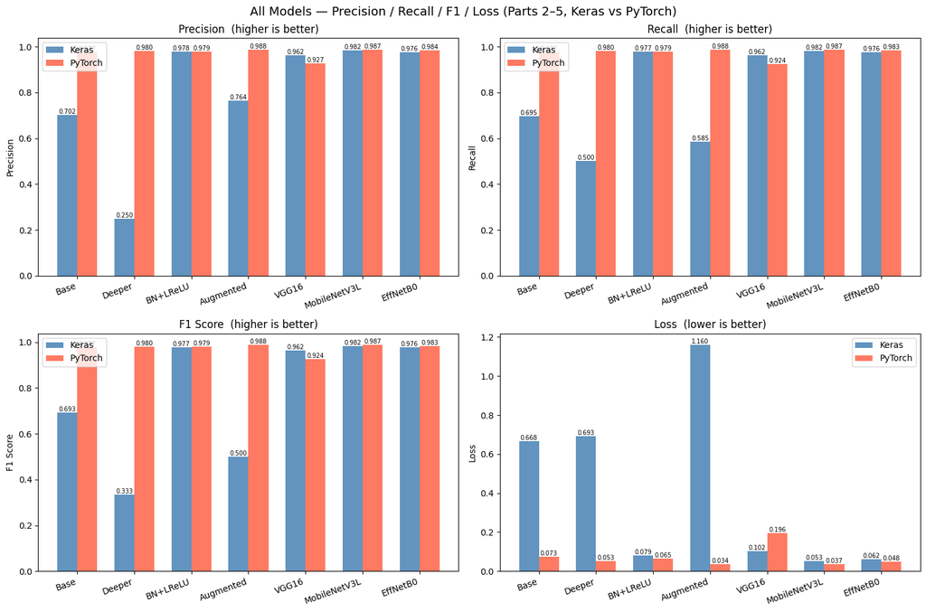

```python
# ── Per-model precision / recall / F1 / loss comparison ─────────────────────
# Builds a 2×2 figure comparing every Keras model from Parts 2/5 against its
# PyTorch counterpart from Parts 3/5 on FOUR metrics:
#   • Precision  (macro-averaged across the two classes)
#   • Recall     (macro-averaged)
#   • F1 score   (macro-averaged)
#   • Loss       (lower is better — already evaluated when the model was
#                  trained, no extra forward pass)
#
# Models that have not been trained yet (their globals are not defined) are
# silently skipped. This matches the tolerant pattern in the master-results
# table above and the bar chart below — you can render this cell at any
# point in Part 5 and it will plot whatever is currently available.
# from sklearn.metrics import precision_recall_fscore_support
import torch
import torch.nn as _torch_nn

def _keras_metrics(model, *, test_gen=None, test_x=None, test_y_int=None,
                   prebuilt_loss=None):
    """Run one forward pass over the test set and compute (P, R, F1, loss)."""
    if model is None:
        return None
    if test_gen is not None:
        test_gen.reset()
        pred = model.predict(test_gen, verbose=0).argmax(axis=1)
        true = test_gen.classes
        loss = float(model.evaluate(test_gen, verbose=0)[0])
    else:
        pred = model.predict(test_x, verbose=0).argmax(axis=1)
        true = test_y_int
        loss = float(prebuilt_loss) if prebuilt_loss is not None else float('nan')
    p, r, f1, _ = precision_recall_fscore_support(
        true, pred, average='macro', zero_division=0)
    return (float(p), float(r), float(f1), loss)

def _torch_metrics(model, loader, *, prebuilt_loss=None):
    """Forward pass over a PyTorch test DataLoader; (P, R, F1, loss)."""
    if model is None or loader is None:
        return None
    crit = _torch_nn.CrossEntropyLoss()
    model.eval()
    preds, trues = [], []
    total_loss, total_n = 0.0, 0
    with torch.no_grad():
        for imgs, labels in loader:
            imgs = imgs.to(DEVICE)
            labels = labels.to(DEVICE)
            out = model(imgs)
            preds.extend(out.argmax(1).cpu().numpy().tolist())
            trues.extend(labels.cpu().numpy().tolist())
            total_loss += float(crit(out, labels).item()) * imgs.size(0)
            total_n    += imgs.size(0)
    p, r, f1, _ = precision_recall_fscore_support(
        trues, preds, average='macro', zero_division=0)
    loss = float(prebuilt_loss) if prebuilt_loss is not None else (total_loss / max(total_n, 1))
    return (float(p), float(r), float(f1), loss)

# Resolve each model and its test source by NAME via globals() so we never
# raise NameError if a particular cell has not been executed yet.
_g = globals()
def _gv(n):
    return _g.get(n)

_keras_specs = [
    # (display_name, model var,  kind, primary, secondary, prebuilt_loss var)
    ('Base Model',          'base_model', 'array', 'test_images_norm', 'test_labels', 'base_loss'),
    ('Model 1 (Deeper)',    'model1',     'array', 'test_images_norm', 'test_labels', 'loss1'),
    ('Model 2 (BN+LReLU)',  'model2',     'array', 'test_images_norm', 'test_labels', 'loss2'),
    ('Model 3 (Augmented)', 'model3',     'array', 'test_images_norm', 'test_labels', 'loss3'),
    ('VGG16 Transfer',      'vgg_model',  'array', 'test_images_norm', 'test_labels', 'vgg_loss'),
    ('EfficientNetB0',      'effb0',      'gen',   'te_eff', None, 'effb0_loss'),
    ('EfficientNetB3 ★',    'effb3',      'gen',   'te_b3',  None, 'effb3_loss'),
    ('ResNet50V2',          'rn50',       'gen',   'te_rn',  None, 'rn50_loss'),
    ('MobileNetV3Large',    'mnv3',       'gen',   'te_mn',  None, 'mnv3_loss'),
]

keras_metrics = {}
for label, mvar, kind, src1, src2, lvar in _keras_specs:
    model = _gv(mvar)
    if model is None:
        continue
    if kind == 'array':
        x = _gv(src1)
        y = _gv(src2)
        if x is None or y is None:
            continue
        keras_metrics[label] = _keras_metrics(
            model, test_x=x, test_y_int=y, prebuilt_loss=_gv(lvar))
    else:  # 'gen'
        gen = _gv(src1)
        if gen is None:
            continue
        keras_metrics[label] = _keras_metrics(model, test_gen=gen)

_torch_specs = [
    ('Base Model',          'pt_base',   'test_loader',         'pt_base_loss'),
    ('Model 1 (Deeper)',    'pt_model1', 'test_loader',         'pt_loss1'),
    ('Model 2 (BN+LReLU)',  'pt_model2', 'test_loader',         'pt_loss2'),
    ('Model 3 (Augmented)', 'pt_model3', 'test_loader',         'pt_loss3'),
    ('VGG16 Transfer',      'pt_vgg',    'vgg_test_loader',     'pt_vgg_loss'),
    ('EfficientNetB0',      'effb0_pt',  'effb0_test_loader',   'pt_effb0_loss'),
    ('EfficientNetB3 ★',    'effb3_pt',  'effb3_test_loader',   'pt_effb3_loss'),
    ('ResNet50V2',          'rn50_pt',   'rn50_test_loader',    'pt_rn50_loss'),
    ('MobileNetV3Large',    'mnv3_pt',   'mnv3_test_loader',    'pt_mnv3_loss'),
]

pytorch_metrics = {}
for label, mvar, lvar_loader, lvar_loss in _torch_specs:
    model = _gv(mvar)
    loader = _gv(lvar_loader)
    if model is None or loader is None:
        continue
    pytorch_metrics[label] = _torch_metrics(
        model, loader, prebuilt_loss=_gv(lvar_loss))

# ── Assemble the 2×2 figure ──────────────────────────────────────────────────
# Index into the (P, R, F1, loss) tuple, with axes labels and direction:
_metric_panels = [
    ('Precision', 0, False),
    ('Recall',    1, False),
    ('F1 Score',  2, False),
    ('Loss',      3, True),
]
# Short labels for the x-axis, mapped to canonical dict keys
_short_to_canon = {
    'Base':         'Base Model',         'Deeper':       'Model 1 (Deeper)',
    'BN+LReLU':     'Model 2 (BN+LReLU)', 'Augmented':    'Model 3 (Augmented)',
    'VGG16':        'VGG16 Transfer',     'ResNet50V2':   'ResNet50V2',
    'MobileNetV3L': 'MobileNetV3Large',   'EffNetB0':     'EfficientNetB0',
    'EffNetB3 ★':   'EfficientNetB3 ★',
}
_short_order = ['Base', 'Deeper', 'BN+LReLU', 'Augmented', 'VGG16',
                'ResNet50V2', 'MobileNetV3L', 'EffNetB0', 'EffNetB3 ★']

_metric_plot_names = [n for n in _short_order
                      if _short_to_canon[n] in keras_metrics
                      and _short_to_canon[n] in pytorch_metrics]
if not _metric_plot_names:
    raise RuntimeError(
        "No model has metrics in BOTH `keras_metrics` and `pytorch_metrics` yet — "
        "train at least one model on each framework before rendering this figure.")

_x = np.arange(len(_metric_plot_names))
_w = 0.35

fig, axes = plt.subplots(2, 2, figsize=(15, 10))
for (title, idx, lower_better), ax in zip(_metric_panels, axes.flat):
    k_vals = [keras_metrics[_short_to_canon[n]][idx]   for n in _metric_plot_names]
    p_vals = [pytorch_metrics[_short_to_canon[n]][idx] for n in _metric_plot_names]
    b1 = ax.bar(_x - _w/2, k_vals, _w, label='Keras',
                color='steelblue', alpha=0.85)
    b2 = ax.bar(_x + _w/2, p_vals, _w, label='PyTorch',
                color='tomato', alpha=0.85)
    ax.set_xticks(_x)
    ax.set_xticklabels(_metric_plot_names, rotation=20, ha='right')
    ax.set_title(f"{title}  ({'lower is better' if lower_better else 'higher is better'})")
    ax.set_ylabel(title)
    ax.legend()
    # value labels above each bar
    for bar in list(b1) + list(b2):
        ax.text(bar.get_x() + bar.get_width() / 2,
                bar.get_height(),
                f'{bar.get_height():.3f}',
                ha='center', va='bottom', fontsize=7)

plt.suptitle('All Models — Precision / Recall / F1 / Loss '
             '(Parts 2–5, Keras vs PyTorch)', fontsize=14)
plt.tight_layout()
plt.show()
```